# The Data Science Pipeline Through Casual Gaming:

-By Ben Angotti

This tutorial is meant to serve as a guide through a Data Scientist's typical exploration of a question and the data used to answer it. Though the work can take many forms and often need repeat steps to fully understand the data, the general flow of tasks can be listed in the following order:

1. Data collection/curation + parsing
2. Data management/representation
3. Exploratory data analysis
4. Hypothesis testing and machine learning
5. Communication of insights attained

Known as the "Data Science Pipeline", these steps are a general explanation of how Data Scientists research and analyze problems.

# Introduction and Context

One of the most popular forms of media in the present age is online gaming. As such, many websites have come to devote themselves to games and their statistics. For any given game, you can find a dozen websites with facts and statistics on every aspect of it, with one of the most popular forms of website being online tier lists. Any game with some sort of competitive nature will develop a tier list for the games various choises, whether it be characters, items, decisions, or any other factor.

League of Legends has grown into an international phenemenon and has numerous sources of data available to aspiring data scientists. As such, dozens of websites have dedicated themselves to gathering and displaying an incredible amount of data to show character (referred to as "champions") viability. This data is often compiled into large tables of numbers and names that are useful for finding single bits of information at a time, but difficult to examine all 150+ champions to search for trends and interesting patterns. This is where the Data Science Pipeline comes in. Using various tools already prepared for use in data analysis, we can extract this data and visualize it in such a way that we can reach new conclusions.

For the sake of this tutorial, I show how to go through each step of the Data Science Pipeline using my personal favorite gamemode, ARAM. ARAM is short for "All Random All Mid", and features a map with a single bridge on which two 5-person teams attempt to capture the others territory. Each team is given a small amount of randomly chosen champions to choose from, giving players a small amount of agency before the game's start.

# Step 0.5 - Importing Libraries

I mentioned that we have available a number of different tools that have already been created for usage in data science. We must import those tools into python so that we can manipulate our data.

```python
#necessary imports to go through data science pipeline
# "requests" will serve as our method of gathering data from our chosen website
import requests
# "pandas" is a wonderful library full of functions that help create dataframes to house large amounts of data
import pandas as pd
# "BeautifulSoup" is an HTML reader that can clean up some difficult to read documents
from bs4 import BeautifulSoup
# "matplotlib" is a graphing library, which will be very helpful in data visualization. There are others, so choose your
# preffered method of graphing if you have experience with those
import matplotlib.pyplot as plt
#Sci-kit learn's (sklearn) linear regression capabilities to model trends
from sklearn import linear_model
```

# Step 1 - Data Collection

The first step of the Data Science Pipeline is to gather the data itself. While there are a great number of choices, this tutorial will focus on a single webpage of statistics for ARAM during the path 11.14. At the time of writing, patch 11.15 has just released, so this data should be somewhat representative of the patch as a whole.

```python
#See if we can reach the data site. The chosen site is the string within the get()
response = requests.get('https://www.metasrc.com/aram/na/stats')
```

```python
#A response of 200 means a successful connection
response
```

```
<Response [200]>
```

```python
#Lets see what we got
#print(response.text)
```

Most webpages will result in a wall of fairly illegible text. This is where BeautfiulSoup comes in handy. We can use its functions to cleanup the text and find the table. If I were to print the example HTML on this tutorial, the page would extend dramatically. I encourage whoever is following this tutorial to try the print statements and see what data you can discern from your webpage's HTML text. Results often vary.

```python
#A more clean version if we need to look it over more
root = BeautifulSoup(response.text, 'html.parser')
#print(root)
```

```python
#We can use the BeautifulSoup interpretation to find the table for us
foundtable = root.find('table').findAll('tr')
#foundtable
```

An alternate method would be to use BeautifulSoup through pandas. Pandas has its own read_html function, and we can specify (the "flavor" variable) which method we desire. Here, we use it along side BeautifulSoup (flavor="bs4)

```python
#Using pandas, we can find all the tables on the website (There are 3)
readtable = pd.read_html(response.text, flavor='bs4')
```

```python
#We only care for the first table with all the stats for each champion
#We delete the "Tier" column as well because it is a subjective view by the website
#We want numbers to reach our own conclusions!
data = readtable[0].drop('Tier', axis=1)
data
```

|  | Name | Primary | Secondary | Score | Trend | Win % | Pick % | KDA |
| --- | --- | --- | --- | --- | --- | --- | --- | --- |
| 0 | AatroxAatrox | Fighter | Tank | 36.58 | -2.09 | 46.39% | 5.61% | 2.66 |
| 1 | AhriAhri | Mage | Assassin | 68.02 | -3.52 | 49.84% | 10.73% | 3.37 |
| 2 | AkaliAkali | Assassin | NaN | 40.86 | -8.75 | 42.83% | 8.15% | 2.64 |
| 3 | AlistarAlistar | Tank | Support | 43.20 | -2.11 | 51.27% | 4.41% | 3.56 |
| 4 | AmumuAmumu | Tank | Mage | 58.77 | +0.11 | 54.19% | 7.07% | 2.81 |
| ... | ... | ... | ... | ... | ... | ... | ... | ... |
| 154 | ZedZed | Assassin | NaN | 46.93 | -6.59 | 44.39% | 8.75% | 2.77 |
| 155 | ZiggsZiggs | Mage | NaN | 71.59 | +4.39 | 53.19% | 9.59% | 4.14 |
| 156 | ZileanZilean | Support | Mage | 50.89 | +7.58 | 49.51% | 6.35% | 4.50 |
| 157 | ZoeZoe | Mage | Support | 41.43 | +4.44 | 43.88% | 7.37% | 3.39 |
| 158 | ZyraZyra | Mage | Support | 57.60 | -1.01 | 54.75% | 5.98% | 3.79 |

159 rows × 8 columns

# Step 2 - Data Management (Cleanup)

Unfortunately, data often comes in forms that make it not usable right off the bat. While the functions we have been provided to graciously have done a great job of gathering the data, they are not perfect. A clear example of this is where the names of each champion have been duplicated. Cleanup is a necessary stage of every scientists journey, and often a lengthy one depending on the data itself. Lets start by cleaning up the "Name" column.

```python
#Loop through the dataframe and chop off half of the names
names = []
for index, row in data.iterrows():
    row['Name'] = row['Name'][:len(row['Name']) // 2]
```

```python
#Now the names column is nice and clean
data
```

|  | Name | Primary | Secondary | Score | Trend | Win % | Pick % | KDA |
| --- | --- | --- | --- | --- | --- | --- | --- | --- |
| 0 | Aatrox | Fighter | Tank | 36.58 | -2.09 | 46.39% | 5.61% | 2.66 |
| 1 | Ahri | Mage | Assassin | 68.02 | -3.52 | 49.84% | 10.73% | 3.37 |
| 2 | Akali | Assassin | NaN | 40.86 | -8.75 | 42.83% | 8.15% | 2.64 |
| 3 | Alistar | Tank | Support | 43.20 | -2.11 | 51.27% | 4.41% | 3.56 |
| 4 | Amumu | Tank | Mage | 58.77 | +0.11 | 54.19% | 7.07% | 2.81 |
| ... | ... | ... | ... | ... | ... | ... | ... | ... |
| 154 | Zed | Assassin | NaN | 46.93 | -6.59 | 44.39% | 8.75% | 2.77 |
| 155 | Ziggs | Mage | NaN | 71.59 | +4.39 | 53.19% | 9.59% | 4.14 |
| 156 | Zilean | Support | Mage | 50.89 | +7.58 | 49.51% | 6.35% | 4.50 |
| 157 | Zoe | Mage | Support | 41.43 | +4.44 | 43.88% | 7.37% | 3.39 |
| 158 | Zyra | Mage | Support | 57.60 | -1.01 | 54.75% | 5.98% | 3.79 |

159 rows × 8 columns

We also grabbed some code along the way and it has worked its way into the dataframe. Notice how there are 159 rows, yet only 155 champions exist during the 11.14 patch.

```python
#We can remove those too, and we accidentally cut in half earlier!
data.loc[data['Name'] == 'zamaf.cmd.push(function() {  zamaf.d']
```

|  | Name | Primary | Secondary | Score | Trend | Win % | Pick % | KDA |
| --- | --- | --- | --- | --- | --- | --- | --- | --- |
| 31 | zamaf.cmd.push(function() { zamaf.d | zamaf.cmd.push(function() { zamaf.displayAsyn... | zamaf.cmd.push(function() { zamaf.displayAsyn... | zamaf.cmd.push(function() { zamaf.displayAsyn... | zamaf.cmd.push(function() { zamaf.displayAsyn... | zamaf.cmd.push(function() { zamaf.displayAsyn... | zamaf.cmd.push(function() { zamaf.displayAsyn... | zamaf.cmd.push(function() { zamaf.displayAsyn... |
| 63 | zamaf.cmd.push(function() { zamaf.d | zamaf.cmd.push(function() { zamaf.displayAsyn... | zamaf.cmd.push(function() { zamaf.displayAsyn... | zamaf.cmd.push(function() { zamaf.displayAsyn... | zamaf.cmd.push(function() { zamaf.displayAsyn... | zamaf.cmd.push(function() { zamaf.displayAsyn... | zamaf.cmd.push(function() { zamaf.displayAsyn... | zamaf.cmd.push(function() { zamaf.displayAsyn... |
| 95 | zamaf.cmd.push(function() { zamaf.d | zamaf.cmd.push(function() { zamaf.displayAsyn... | zamaf.cmd.push(function() { zamaf.displayAsyn... | zamaf.cmd.push(function() { zamaf.displayAsyn... | zamaf.cmd.push(function() { zamaf.displayAsyn... | zamaf.cmd.push(function() { zamaf.displayAsyn... | zamaf.cmd.push(function() { zamaf.displayAsyn... | zamaf.cmd.push(function() { zamaf.displayAsyn... |
| 127 | zamaf.cmd.push(function() { zamaf.d | zamaf.cmd.push(function() { zamaf.displayAsyn... | zamaf.cmd.push(function() { zamaf.displayAsyn... | zamaf.cmd.push(function() { zamaf.displayAsyn... | zamaf.cmd.push(function() { zamaf.displayAsyn... | zamaf.cmd.push(function() { zamaf.displayAsyn... | zamaf.cmd.push(function() { zamaf.displayAsyn... | zamaf.cmd.push(function() { zamaf.displayAsyn... |

```python
#We can clear them out as well
data = data.loc[data['Name'] != 'zamaf.cmd.push(function() {  zamaf.d']
data
```

|  | Name | Primary | Secondary | Score | Trend | Win % | Pick % | KDA |
| --- | --- | --- | --- | --- | --- | --- | --- | --- |
| 0 | Aatrox | Fighter | Tank | 36.58 | -2.09 | 46.39% | 5.61% | 2.66 |
| 1 | Ahri | Mage | Assassin | 68.02 | -3.52 | 49.84% | 10.73% | 3.37 |
| 2 | Akali | Assassin | NaN | 40.86 | -8.75 | 42.83% | 8.15% | 2.64 |
| 3 | Alistar | Tank | Support | 43.20 | -2.11 | 51.27% | 4.41% | 3.56 |
| 4 | Amumu | Tank | Mage | 58.77 | +0.11 | 54.19% | 7.07% | 2.81 |
| ... | ... | ... | ... | ... | ... | ... | ... | ... |
| 154 | Zed | Assassin | NaN | 46.93 | -6.59 | 44.39% | 8.75% | 2.77 |
| 155 | Ziggs | Mage | NaN | 71.59 | +4.39 | 53.19% | 9.59% | 4.14 |
| 156 | Zilean | Support | Mage | 50.89 | +7.58 | 49.51% | 6.35% | 4.50 |
| 157 | Zoe | Mage | Support | 41.43 | +4.44 | 43.88% | 7.37% | 3.39 |
| 158 | Zyra | Mage | Support | 57.60 | -1.01 | 54.75% | 5.98% | 3.79 |

155 rows × 8 columns

The next step of cleanup is a bit tricky to spot at first. Each column is stored as its own datatype and therefore needs to be assigned accordingly. Numerical columns, such as "Pick %" and "Win %" can sometimes contain non-numeric symbols. In this case, they contain the "%" symbol, and must be cast to numerical values. Even the "KDA" column is currently not labeled as numeric, because our code believes the decimal point to be a character instead of a numerical seperator.

```python
#We need Numbers for graphing, so they need to be converted
#we can use the same method we used for the names, with some intermediate values to keep the code clean
for index, row in data.iterrows():
    currwin = row['Win %']
    currpick = row['Pick %']
    currkd = row['KDA']
    row['Win %'] = float(currwin[:len(currwin) - 1])
    row['Pick %'] = float(currpick[:len(currpick) - 1])
    row['KDA'] = float(currkd)

data
```

|  | Name | Primary | Secondary | Score | Trend | Win % | Pick % | KDA |
| --- | --- | --- | --- | --- | --- | --- | --- | --- |
| 0 | Aatrox | Fighter | Tank | 36.58 | -2.09 | 46.39 | 5.61 | 2.66 |
| 1 | Ahri | Mage | Assassin | 68.02 | -3.52 | 49.84 | 10.73 | 3.37 |
| 2 | Akali | Assassin | NaN | 40.86 | -8.75 | 42.83 | 8.15 | 2.64 |
| 3 | Alistar | Tank | Support | 43.20 | -2.11 | 51.27 | 4.41 | 3.56 |
| 4 | Amumu | Tank | Mage | 58.77 | +0.11 | 54.19 | 7.07 | 2.81 |
| ... | ... | ... | ... | ... | ... | ... | ... | ... |
| 154 | Zed | Assassin | NaN | 46.93 | -6.59 | 44.39 | 8.75 | 2.77 |
| 155 | Ziggs | Mage | NaN | 71.59 | +4.39 | 53.19 | 9.59 | 4.14 |
| 156 | Zilean | Support | Mage | 50.89 | +7.58 | 49.51 | 6.35 | 4.5 |
| 157 | Zoe | Mage | Support | 41.43 | +4.44 | 43.88 | 7.37 | 3.39 |
| 158 | Zyra | Mage | Support | 57.60 | -1.01 | 54.75 | 5.98 | 3.79 |

155 rows × 8 columns

It is important to note that the Data Science Pipeline is not always a linear track through science. Often times, the scientist will have to backtrack and repeat a step or two in order to progress forward. Sometimes more data is needed, and so they temporarily return to the first step to gather more. In the case of this tutorial, I had failed to notice that the integers were not stored as such until I attempted to graph them. Graphing non-integers led to some unfortunate looking graphs, so I had to revisit the cleanup stage. For the sake of clarity, I have grouped all aspects of cleanup together, but be aware that you will often not notice all the details about your data when you first receive it.

As an aside, I am leaving the "Score" and "Trend" columns alone for now, as they are useful for reference, but not needed for visualization at this time.

It is also worth noting that the "Secondary" column features a number of missing values (listed as NaN). This is because some champions only fulfil one role (Purely a mage, or purely support). We would describe this as "Data Missing Not At Random", or MNAR, because we are aware of exactly why the data is missing. Typically, we would have to decide whether or not to involve data with missing entries in our evaluation, or come up with a model to fill the gaps, but since we are aware of why the data is missing, we can instead use it later down the line.

# Step 3 - Exploratory Data Analysis (Visualization)

Once we have reached a point where we believe our data is clean enough to be explored, we can start looking for interesting trends. Before proceeding however, it is important to clarify what trend we are actually looking to identify. This will give us direction when we examine the resulting graphs and output, and often requires some insight into the topic at hand. In the case of ARAM in League of Legends, I have accumulated some personal experience that has led to ideas I have had about the gamemode. My desire to confirm or disprove these ideas is what led me to choose this topic for exploration, and drives the data Science Pipeline as a whole.

ARAM has a couple of additional rules outside of its semi-randomness and interesting map design (being a single lane with teams on either side). The player is not allowed to return to their base and heal up battle wounds. In addition, the player is only able to acquire additional items after dying. This leads to a game flow where the player is encouraged to take care of their Health Points and choose moments of battle wisely. For this reason and the lack of space to maneuver due to map design, I believe Mages are the superior champion type to use in ARAM. Mages often have spells that cover a large area, or have the range to cast them from a safe distance. This allows them to slowly build an advantage against the enemy team, and take fights once they feel they can easily win them, and therefore see better performance numbers.

In addition to my own hypothesis, there is also the Null-Hypothesis, which would state that there is no significant statistical difference between populations. In this case, the Null-Hypothesis would suggest that there would be no significant performance difference between champion type.

Finally, we should also see if there are any discernable relationships between our major three columns: Win %, Pick %, and KDA. If any trends are present, we may able to build a model to predict champion performance.

The first graph I decided to check was to see if champions that were picked more often were more successful than those who were not. For context, despite ARAM being "all random", the actual process allows players to select a champion from a select few random options. For the sake of examination, we will operate under the assumption that each champion is offered at nearly the same amount. There is unfortuantely no way to measure the rates at which champions are actually offered currently, making this assumption neccessary.

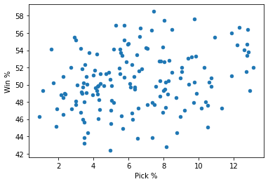

```python
#matplotlib and pandas work together to easily craft plots of dataframes
plt.figure()
data.plot.scatter(x='Pick %', y='Win %')
```

This data seems quite spread out, which is not necessarily bad. My assumption that people will pick based on who they believe will give them the best chance of winning does not account for all possible options. Often times players may select a champion that they simply enjoy playing, or choose a champion that they are unskilled at as they were not given any familiar options. The randomness here was almost expected in hindsight. A more revealing graph may be to examine a champions average perfomance during a match. Listed as the "KDA" column, this represents the champions takedowns vs deaths in a simple ratio. Theoritically, the more takedowns one acquires during a match, the more likely they are to win.

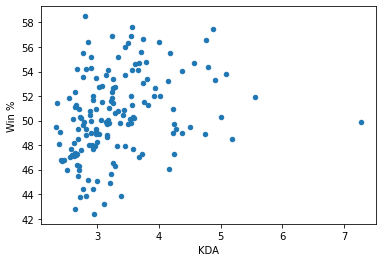

```python
#swap out pick% for KDA
plt.figure()
data.plot.scatter(x='KDA', y='Win %')
```

The data does seem to cluster a bit closer together, but now there is an incredible outlier. Lets examine who it is...

```python
#The outlier seems to be the only champion with a KDA above 7
data.loc[data['KDA'] > 7]
```

|  | Name | Primary | Secondary | Score | Trend | Win % | Pick % | KDA |
| --- | --- | --- | --- | --- | --- | --- | --- | --- |
| 152 | Yuumi | Support | Mage | 53.09 | -0.17 | 49.86 | 5.03 | 7.27 |

Yuumi is a Support/Mage champion with a special power to become undamageable by attaching herself to an ally. This gives her a clear advantage when it comes to avoiding combat, which would explain how she has such a high takedowns vs deaths ratio.

Next, lets revisit the first idea where we checked if someone would choose a champion based on win rate. If KDA is a better metric of champion performance in-game, perhaps it is worth investigating if it effects a champions pick %...

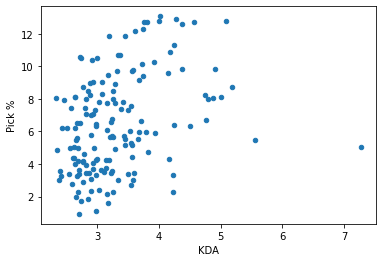

```python
plt.figure()
data.plot.scatter(x='KDA', y='Pick %')
```

Again, the data seems to shift together compared to the first graph, suggesting there may be some correlation. We will explore this more in Step 4, where we fit lines to the graphs.

As an aside, we can also examine the average winrate of all champions across all types. The company that balances League of Legends (RIOT Games) has stated that the ideal would be if each champion has a %50 win rate. It is evident from the graphs that they are far from reaching this in ARAM, most likely because they balance around the League's primary gamemode, "Summoner's Rift". However it is worth noting that the average winrate across all champions is at %50, meaning the player is given an even chance of receiving a champion above or below that threshold during the selection phase.

```python
#average
data['Win %'].sum()/ 155
```

```
50.406967741935475
```

I saved the most interesting plot for last. The scatter plots serve well at examining trends, but my hypothesis focused on the roles each champion played. Instead of plotting each role as their own scatter plot, we can more efficiently examine their data using a violin plot. A violin plot allows us to measure spread of a category by grouping each role into its own set, and then displaying them next to each other on the same graph.

```python
#tell dataframe that these columns are numbers
data[['Win %', 'Pick %', 'KDA']] = data[['Win %', 'Pick %', 'KDA']].apply(pd.to_numeric) #results in warning!

#seperates each role's win % into seperate lists
#it is also important to note that we will focus on "Primary" role, as it best describes a champion's playstyle
winp_by_role = [data.loc[data['Primary'] == 'Fighter']['Win %'],\
               data.loc[data['Primary'] == 'Mage']['Win %'],\
               data.loc[data['Primary'] == 'Assassin']['Win %'],\
               data.loc[data['Primary'] == 'Tank']['Win %'],\
               data.loc[data['Primary'] == 'Marksman']['Win %'],\
               data.loc[data['Primary'] == 'Support']['Win %']]
```

[output not shown]

The warning we are given is because the violin plot expects the data to be numeric. As mentioned earlier during cleanup, the numeric values were not initially saved as numbers, and despite casting them for scatter plots, the dataframe still believes they are not. Since we are overwriting an entire column, pandas is using a reference to the new columns and the dataframe. This could lead to reference problems in the future, but for our sake, it can be ignored.

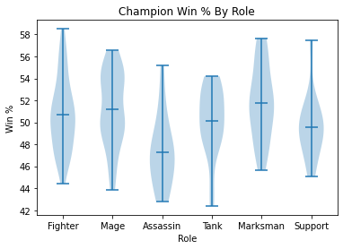

```python
#violin plot of champ role to Win Rate
fig, ax = plt.subplots()
ax.violinplot(winp_by_role,showmeans=True)
plt.xticks([1,2,3,4,5,6], data['Primary'].unique())
ax.set_xlabel("Role")
ax.set_ylabel("Win %")
ax.set_title("Champion Win % By Role")
#fig.savefig('Violin Roles.png') #--> this line allows you to save the graph if you like
```

The violin plot reveals some incredibly interesting statistics. Each role seems to be unimodal (only one area where the distribution "bulges"), with the exception of Mages. The line in the center of each represents the average win ratio for that classification. Finally, the range is represented as the height of each grouping.

We can discern from the graph that not all champions are performing equally within their respective role. Take for example the "Fighter" and "Assassin" graphs. They both have high upper ranges but seem to have their largest "bulge" be slightly below their means. This means that the majority of champions of those type are performing worse than their average, with a couple overperformers that drag the mean up. In contrast, the "Marksman" plot is practically symmetrical, implying they perform fairly consistently regardless of selection. The "Tank" and "Support" roles seem to be reverses of another, with one having underperformers and the other having overperformers respectively.

The "Mage" role having two "bulges" suggests that there are two groupings of Mages that either perform above or below average. We can further investigate by comparing Mages by their secondary role.

```python
#isolate mages into their own dataframe
magedf = data.loc[data['Primary'] == 'Mage']
```

```python
#group similar to before, but based off dataframe of Mages and by secondary role
#note that some mages do not have a secondary, and so their data is "missing"
winp_by_mage = [magedf.loc[magedf['Secondary'] == 'Assassin']['Win %'],\
               magedf.loc[magedf['Secondary'] == 'Support']['Win %'],\
               magedf.loc[magedf['Secondary'].isnull()]['Win %'],\
               magedf.loc[magedf['Secondary'] == 'Marksman']['Win %'],\
               magedf.loc[magedf['Secondary'] == 'Fighter']['Win %']]
```

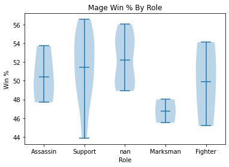

```python
fig, ax = plt.subplots()
ax.violinplot(winp_by_mage,showmeans=True)
plt.xticks([1,2,3,4,5], magedf['Secondary'].unique())
ax.set_xlabel("Role")
ax.set_ylabel("Win %")
ax.set_title("Mage Win % By Role")
```

Here we run into a small issue. As we have become so specific with our data, the violin plot is having trouble graphing the "bulges". Certain categories simply do not have enough data to form a well illustrated graph (there are only two mages who's secondary role is marksman), whereas others have plenty (there are quite a few pure mages or mage/supports).

We can still tell a great deal from this graph by examining similar features as the previous graph. To further investigate would require examining individual champions and finding a new way to classify them, as the pure mages plot is still bimodal. A good place to start would be to find data on champion difficulty, as perhaps more difficult to play champions perform worse, or some other possibility.

# Step 4 - Hypothesis Testing and Machine Learning

Now that we have the graphs and some idea of what the data looks like, we can try fitting models to them in hopes of more accurately identifying trends. We can plot linear regressions onto the scatter plots to see if they line up well with our assumptions.

An important note to keep in mind is that no matter what model we use, we will receieve a result. Simply getting a result from modelling does not guarantee it is a meaningful result. For example, the first graph we examined was Pick % vs Win %, to which we stated the data was quite noisy with no clear trend. We can still fit a model to this as follows...

```python
#fit a model to the data and attempt to predict win rate by pick %
#the linear model (y=mx+b) is printed below
reg = linear_model.LinearRegression()
reg.fit(data['Pick %'].values.reshape(-1,1), data['Win %'].values.reshape(-1,1))
print("Win % = (" + str(reg.coef_[0][0]) + " * [Pick %]) + " + str(reg.intercept_[0]))
```

```
Win % = (0.29029501611433484 * [Pick %]) + 48.52928339157582
```

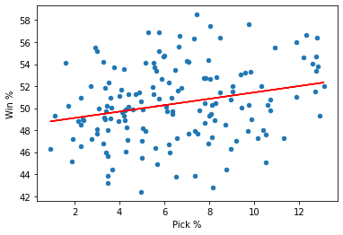

```python
#plot the first graph again, as well as the predictive line
plt.figure()
data.plot.scatter(x='Pick %', y='Win %')
#using the trained linear model, we can plot points based on predicted values to show the linear regression
plt.plot(data['Pick %'].values.reshape(-1,1), reg.predict(data['Pick %'].values.reshape(-1,1)), color='red')
```

At this stage of the Data Science Pipeline, the scientist must decide whether the model is of any value given the data present. We assume that data has a relationship, and when we use a linear model, we also must assume that that relationship is linear. It is entirely possible that the data could simply be too noisy to confidently make these assumptions, which I would say is evident from this graph.

Lets examine the other two graphs, where the data points seemed to clusted a bit closer together.

```python
reg = linear_model.LinearRegression()
reg.fit(data['KDA'].values.reshape(-1,1), data['Win %'].values.reshape(-1,1))
print("Win % = (" + str(reg.coef_[0][0]) + " * [KDA]) + " + str(reg.intercept_[0]))
```

```
Win % = (1.4189496478845447 * [KDA]) + 45.70914586577476
```

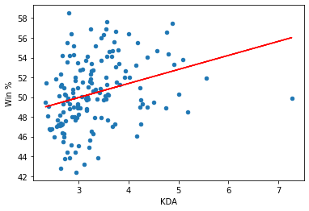

```python
plt.figure()
data.plot.scatter(x='KDA', y='Win %')
plt.plot(data['KDA'].values.reshape(-1,1), reg.predict(data['KDA'].values.reshape(-1,1)), color='red')
```

```python
reg = linear_model.LinearRegression()
reg.fit(data['KDA'].values.reshape(-1,1), data['Pick %'].values.reshape(-1,1))
print("Pick % = (" + str(reg.coef_[0][0]) + " * [KDA]) + " + str(reg.intercept_[0]))
```

```
Pick % = (1.4410016327563933 * [KDA]) + 1.6973625297961394
```

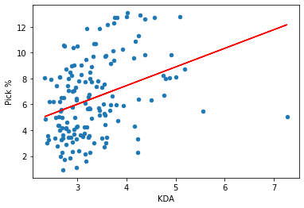

```python
plt.figure()
data.plot.scatter(x='KDA', y='Pick %')
plt.plot(data['KDA'].values.reshape(-1,1), reg.predict(data['KDA'].values.reshape(-1,1)), color='red')
```

I had expected both lines to have slightly better correlation, but perhaps the data is too noisy to truly say our models serve as accurate predictors. The slope of the lines increases with each successive graph, which would make sense as the data seems to cluster towards one side, but does not necessarily imply a strong relationship.

As a final attempt, lets revisit the Data Visualization stage and create one final graph to model. If we flip the axis of the third graph, we can instead see if a champion's Pick % affects their average takedown ratio.

```
KDA = (0.08472542635083091 * [Pick %]) + 2.7627537374415962
```

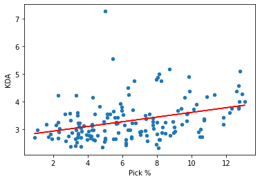

```python
reg = linear_model.LinearRegression()
reg.fit(data['Pick %'].values.reshape(-1,1), data['KDA'].values.reshape(-1,1))
print("KDA = (" + str(reg.coef_[0][0]) + " * [Pick %]) + " + str(reg.intercept_[0]))

plt.figure()
data.plot.scatter(x='Pick %', y='KDA')
plt.plot(data['Pick %'].values.reshape(-1,1), reg.predict(data['Pick %'].values.reshape(-1,1)), color='red')
```

This model seems to have the data points line up better, but is still quite noisy. At this point, it may be worth looking towards other models, or perhaps begin searching for new relationships within other sets of data. It is up to the data scientist to decide on the value of the models they create during this stage of the pipeline.

# Step 5 - Communication of Insights Attained

From The models we created, it would be difficult to say that a champion's Win %, Pick %, or KDA are dependant upon eachother in any fashion when it comes to ARAM exclusive statistics. Each model had large amounts of noise that, while a line was able to be fit, does not seem to produce trustowrthy results. This result was not altogether unexpected however. ARAM is, in reference to League of Legends as a whole, a secondary gamemode meant for players to take a break from the main game. It is treated as a more casual experience, and hardly ever receieves balance updates in comparison to Summoner's Rift. Players treat the mode as a place to mess around and have fun, often times losing as a result of a fun decision that costs them the game. The randomness plays a major role as well, as it often forces players into situations they are often unprepared for. Perhaps the lack of correlation is more telling than if a trend had been found.

# Where to go next?

With both hypotheses still in play, it may be worth it to investigate a new point of view with new data. I had mentioned earlier that champion difficulty may play a major role in this data as well. There certainly exists measures of champion difficulty, so they would need to be evaluated before starting again with a new dataframe. We also did not make use of the "Trend" column, which offers insight into how the champion is performing in reference to the previous patch. It could be worth exploring individual champions performance over multiple patches to see if we could predict their future abilities.

In regards to modeling and practice, I would recommend trying from a more consistent environment. I chose ARAM as my base of data as I thought the randomness would have some interesting effects on data (with which I am not disappointed). However, randomness often needs explaining and sometimes can never truly be pushed aside. A better environment for proving champion performance would certainly be the ranked format of League of Legends main gamemode, Summoner's Rift. The game is updated with this mode specifically as the focal point of design, so it would likely yield some interesting trends. One could also break apart the gamemode into its individual ranks, and see if performance varies via ranking (Bronze tier players may be worse than Platinum tier players at certain champions.

Regardless, the Data Science Pipeline trustworthy process used to examine all sorts of valuable data, even if we did just use it to examine a the casual experience of a popular online game. I hope this tutorial helped further your understanding of Data Science as a topic, and inspired you to seek your own conclusions in science!